# Risk Factor Analysis

## Outcome Variable

**Outcome Variable:** y_rate_len

## Predictor Variables

**Intervention Variable:** predfeed6

**Adjustment Set:**

- arm
- sex
- month
- brthmon
- W_mage
- meducyrs
- feducyrs
- hhwealth_quart
- hfoodsec
- W_mhtcm
- W_mwtkg
- W_mbmi
- vagbrth
- W_birthwt
- W_birthlen
- single
- W_nrooms
- impfloor
- impsan
- safeh20
- delta_W_mage
- delta_meducyrs
- delta_feducyrs
- delta_hhwealth_quart
- delta_hfoodsec
- delta_W_mhtcm
- delta_W_mwtkg
- delta_W_mbmi
- delta_vagbrth
- delta_W_birthwt
- delta_W_birthlen
- delta_single
- delta_W_nrooms
- delta_impfloor
- delta_impsan
- delta_safeh20

## Stratifying Variables

The analysis was stratified on these variable(s):

- agecat
- studyid
- country

## Data Summary

| agecat | studyid | country | predfeed6 | n_cell | n |
| --- | --- | --- | --- | --- | --- |
| 0-3 months | EE | PAKISTAN | 1 | 33 | 37 |
| 0-3 months | EE | PAKISTAN | 0 | 4 | 37 |
| 0-3 months | GMS-Nepal | NEPAL | 1 | 368 | 501 |
| 0-3 months | GMS-Nepal | NEPAL | 0 | 133 | 501 |
| 0-3 months | JiVitA-3 | BANGLADESH | 1 | 9260 | 11961 |
| 0-3 months | JiVitA-3 | BANGLADESH | 0 | 2701 | 11961 |
| 0-3 months | JiVitA-4 | BANGLADESH | 1 | 1512 | 1805 |
| 0-3 months | JiVitA-4 | BANGLADESH | 0 | 293 | 1805 |
| 0-3 months | MAL-ED | BANGLADESH | 1 | 82 | 227 |
| 0-3 months | MAL-ED | BANGLADESH | 0 | 145 | 227 |
| 0-3 months | MAL-ED | BRAZIL | 1 | 21 | 163 |
| 0-3 months | MAL-ED | BRAZIL | 0 | 142 | 163 |
| 0-3 months | MAL-ED | INDIA | 1 | 8 | 167 |
| 0-3 months | MAL-ED | INDIA | 0 | 159 | 167 |
| 0-3 months | MAL-ED | NEPAL | 1 | 11 | 145 |
| 0-3 months | MAL-ED | NEPAL | 0 | 134 | 145 |
| 0-3 months | MAL-ED | PERU | 1 | 85 | 254 |
| 0-3 months | MAL-ED | PERU | 0 | 169 | 254 |
| 0-3 months | MAL-ED | SOUTH AFRICA | 1 | 2 | 186 |
| 0-3 months | MAL-ED | SOUTH AFRICA | 0 | 184 | 186 |
| 0-3 months | MAL-ED | TANZANIA, UNITED REPUBLIC OF | 1 | 0 | 211 |
| 0-3 months | MAL-ED | TANZANIA, UNITED REPUBLIC OF | 0 | 211 | 211 |
| 3-6 months | EE | PAKISTAN | 1 | 34 | 38 |
| 3-6 months | EE | PAKISTAN | 0 | 4 | 38 |
| 3-6 months | GMS-Nepal | NEPAL | 1 | 338 | 464 |
| 3-6 months | GMS-Nepal | NEPAL | 0 | 126 | 464 |
| 3-6 months | JiVitA-3 | BANGLADESH | 1 | 5753 | 7502 |
| 3-6 months | JiVitA-3 | BANGLADESH | 0 | 1749 | 7502 |
| 3-6 months | JiVitA-4 | BANGLADESH | 1 | 1516 | 1797 |
| 3-6 months | JiVitA-4 | BANGLADESH | 0 | 281 | 1797 |

[output cut: 150 more lines]

The following strata were considered:

- agecat: 0-3 months, studyid: EE, country: PAKISTAN
- agecat: 0-3 months, studyid: GMS-Nepal, country: NEPAL
- agecat: 0-3 months, studyid: JiVitA-3, country: BANGLADESH
- agecat: 0-3 months, studyid: JiVitA-4, country: BANGLADESH
- agecat: 0-3 months, studyid: MAL-ED, country: BANGLADESH
- agecat: 0-3 months, studyid: MAL-ED, country: BRAZIL
- agecat: 0-3 months, studyid: MAL-ED, country: INDIA
- agecat: 0-3 months, studyid: MAL-ED, country: NEPAL
- agecat: 0-3 months, studyid: MAL-ED, country: PERU
- agecat: 0-3 months, studyid: MAL-ED, country: SOUTH AFRICA
- agecat: 0-3 months, studyid: MAL-ED, country: TANZANIA, UNITED REPUBLIC OF
- agecat: 12-15 months, studyid: EE, country: PAKISTAN
- agecat: 12-15 months, studyid: GMS-Nepal, country: NEPAL
- agecat: 12-15 months, studyid: JiVitA-4, country: BANGLADESH
- agecat: 12-15 months, studyid: LCNI-5, country: MALAWI
- agecat: 12-15 months, studyid: MAL-ED, country: BANGLADESH
- agecat: 12-15 months, studyid: MAL-ED, country: BRAZIL
- agecat: 12-15 months, studyid: MAL-ED, country: INDIA
- agecat: 12-15 months, studyid: MAL-ED, country: NEPAL
- agecat: 12-15 months, studyid: MAL-ED, country: PERU
- agecat: 12-15 months, studyid: MAL-ED, country: SOUTH AFRICA
- agecat: 12-15 months, studyid: MAL-ED, country: TANZANIA, UNITED REPUBLIC OF
- agecat: 12-15 months, studyid: SAS-FoodSuppl, country: INDIA
- agecat: 15-18 months, studyid: EE, country: PAKISTAN
- agecat: 15-18 months, studyid: GMS-Nepal, country: NEPAL
- agecat: 15-18 months, studyid: JiVitA-4, country: BANGLADESH
- agecat: 15-18 months, studyid: LCNI-5, country: MALAWI
- agecat: 15-18 months, studyid: MAL-ED, country: BANGLADESH
- agecat: 15-18 months, studyid: MAL-ED, country: BRAZIL
- agecat: 15-18 months, studyid: MAL-ED, country: INDIA
- agecat: 15-18 months, studyid: MAL-ED, country: NEPAL
- agecat: 15-18 months, studyid: MAL-ED, country: PERU
- agecat: 15-18 months, studyid: MAL-ED, country: SOUTH AFRICA
- agecat: 15-18 months, studyid: MAL-ED, country: TANZANIA, UNITED REPUBLIC OF
- agecat: 15-18 months, studyid: SAS-FoodSuppl, country: INDIA
- agecat: 18-21 months, studyid: EE, country: PAKISTAN
- agecat: 18-21 months, studyid: GMS-Nepal, country: NEPAL
- agecat: 18-21 months, studyid: LCNI-5, country: MALAWI
- agecat: 18-21 months, studyid: MAL-ED, country: BANGLADESH
- agecat: 18-21 months, studyid: MAL-ED, country: BRAZIL
- agecat: 18-21 months, studyid: MAL-ED, country: INDIA
- agecat: 18-21 months, studyid: MAL-ED, country: NEPAL
- agecat: 18-21 months, studyid: MAL-ED, country: PERU
- agecat: 18-21 months, studyid: MAL-ED, country: SOUTH AFRICA
- agecat: 18-21 months, studyid: MAL-ED, country: TANZANIA, UNITED REPUBLIC OF
- agecat: 21-24 months, studyid: EE, country: PAKISTAN
- agecat: 21-24 months, studyid: GMS-Nepal, country: NEPAL
- agecat: 21-24 months, studyid: LCNI-5, country: MALAWI
- agecat: 21-24 months, studyid: MAL-ED, country: BANGLADESH
- agecat: 21-24 months, studyid: MAL-ED, country: BRAZIL
- agecat: 21-24 months, studyid: MAL-ED, country: INDIA
- agecat: 21-24 months, studyid: MAL-ED, country: NEPAL
- agecat: 21-24 months, studyid: MAL-ED, country: PERU
- agecat: 21-24 months, studyid: MAL-ED, country: SOUTH AFRICA
- agecat: 21-24 months, studyid: MAL-ED, country: TANZANIA, UNITED REPUBLIC OF
- agecat: 3-6 months, studyid: EE, country: PAKISTAN
- agecat: 3-6 months, studyid: GMS-Nepal, country: NEPAL
- agecat: 3-6 months, studyid: JiVitA-3, country: BANGLADESH
- agecat: 3-6 months, studyid: JiVitA-4, country: BANGLADESH
- agecat: 3-6 months, studyid: MAL-ED, country: BANGLADESH
- agecat: 3-6 months, studyid: MAL-ED, country: BRAZIL
- agecat: 3-6 months, studyid: MAL-ED, country: INDIA
- agecat: 3-6 months, studyid: MAL-ED, country: NEPAL
- agecat: 3-6 months, studyid: MAL-ED, country: PERU
- agecat: 3-6 months, studyid: MAL-ED, country: SOUTH AFRICA
- agecat: 3-6 months, studyid: MAL-ED, country: TANZANIA, UNITED REPUBLIC OF
- agecat: 6-9 months, studyid: EE, country: PAKISTAN
- agecat: 6-9 months, studyid: GMS-Nepal, country: NEPAL
- agecat: 6-9 months, studyid: JiVitA-4, country: BANGLADESH
- agecat: 6-9 months, studyid: LCNI-5, country: MALAWI
- agecat: 6-9 months, studyid: MAL-ED, country: BANGLADESH
- agecat: 6-9 months, studyid: MAL-ED, country: BRAZIL
- agecat: 6-9 months, studyid: MAL-ED, country: INDIA
- agecat: 6-9 months, studyid: MAL-ED, country: NEPAL
- agecat: 6-9 months, studyid: MAL-ED, country: PERU
- agecat: 6-9 months, studyid: MAL-ED, country: SOUTH AFRICA
- agecat: 6-9 months, studyid: MAL-ED, country: TANZANIA, UNITED REPUBLIC OF
- agecat: 6-9 months, studyid: SAS-FoodSuppl, country: INDIA
- agecat: 9-12 months, studyid: EE, country: PAKISTAN
- agecat: 9-12 months, studyid: GMS-Nepal, country: NEPAL
- agecat: 9-12 months, studyid: JiVitA-4, country: BANGLADESH
- agecat: 9-12 months, studyid: LCNI-5, country: MALAWI
- agecat: 9-12 months, studyid: MAL-ED, country: BANGLADESH
- agecat: 9-12 months, studyid: MAL-ED, country: BRAZIL
- agecat: 9-12 months, studyid: MAL-ED, country: INDIA
- agecat: 9-12 months, studyid: MAL-ED, country: NEPAL
- agecat: 9-12 months, studyid: MAL-ED, country: PERU
- agecat: 9-12 months, studyid: MAL-ED, country: SOUTH AFRICA
- agecat: 9-12 months, studyid: MAL-ED, country: TANZANIA, UNITED REPUBLIC OF
- agecat: 9-12 months, studyid: SAS-FoodSuppl, country: INDIA

### Dropped Strata

Some strata were dropped due to rare outcomes:

- agecat: 0-3 months, studyid: EE, country: PAKISTAN
- agecat: 0-3 months, studyid: MAL-ED, country: SOUTH AFRICA
- agecat: 0-3 months, studyid: MAL-ED, country: TANZANIA, UNITED REPUBLIC OF
- agecat: 3-6 months, studyid: EE, country: PAKISTAN
- agecat: 3-6 months, studyid: MAL-ED, country: SOUTH AFRICA
- agecat: 3-6 months, studyid: MAL-ED, country: TANZANIA, UNITED REPUBLIC OF
- agecat: 6-9 months, studyid: MAL-ED, country: SOUTH AFRICA
- agecat: 6-9 months, studyid: MAL-ED, country: TANZANIA, UNITED REPUBLIC OF
- agecat: 6-9 months, studyid: SAS-FoodSuppl, country: INDIA
- agecat: 9-12 months, studyid: MAL-ED, country: SOUTH AFRICA
- agecat: 9-12 months, studyid: MAL-ED, country: TANZANIA, UNITED REPUBLIC OF
- agecat: 9-12 months, studyid: SAS-FoodSuppl, country: INDIA
- agecat: 12-15 months, studyid: LCNI-5, country: MALAWI
- agecat: 12-15 months, studyid: MAL-ED, country: SOUTH AFRICA
- agecat: 12-15 months, studyid: MAL-ED, country: TANZANIA, UNITED REPUBLIC OF
- agecat: 12-15 months, studyid: SAS-FoodSuppl, country: INDIA
- agecat: 15-18 months, studyid: LCNI-5, country: MALAWI
- agecat: 15-18 months, studyid: MAL-ED, country: SOUTH AFRICA
- agecat: 15-18 months, studyid: MAL-ED, country: TANZANIA, UNITED REPUBLIC OF
- agecat: 15-18 months, studyid: SAS-FoodSuppl, country: INDIA
- agecat: 18-21 months, studyid: MAL-ED, country: SOUTH AFRICA
- agecat: 18-21 months, studyid: MAL-ED, country: TANZANIA, UNITED REPUBLIC OF
- agecat: 21-24 months, studyid: EE, country: PAKISTAN
- agecat: 21-24 months, studyid: MAL-ED, country: SOUTH AFRICA
- agecat: 21-24 months, studyid: MAL-ED, country: TANZANIA, UNITED REPUBLIC OF

## Methods Detail

We’re interested in the causal parameters $E[Y_a]$ for all values of $a \in \mathcal{A}$. These parameters represent the mean outcome if, possibly contrary to fact, we intervened to set all units to have $A=a$. Under the randomization and positivity assumptions, these are identified by the statistical parameters $\psi_a=E_W[E_{Y|A,W}(Y|A=a,W)]$. In addition, we’re interested in the mean of $Y$, $E[Y]$ under no intervention (the observed mean). We will estimate these parameters by using SuperLearner to fit the relevant likelihood factors – $E_{Y|A,W}(Y|A=a,W)$ and $p(A=a|W)$, and then updating our likelihood fit using a joint TMLE.

For unadjusted analyses ($W=\{\}$), initial likelihoods were estimated using Lrnr_glm to estimate the simple $E(Y|A)$ and Lrnr_mean to estimate $p(A)$. For adjusted analyses, a small library containing Lrnr_glmnet, Lrnr_xgboost, and Lrnr_mean was used.

Having estimated these parameters, we will then use the delta method to estimate relative risks and attributable risks relative to a prespecified baseline level of $A$.

# Results Detail

## Results Plots

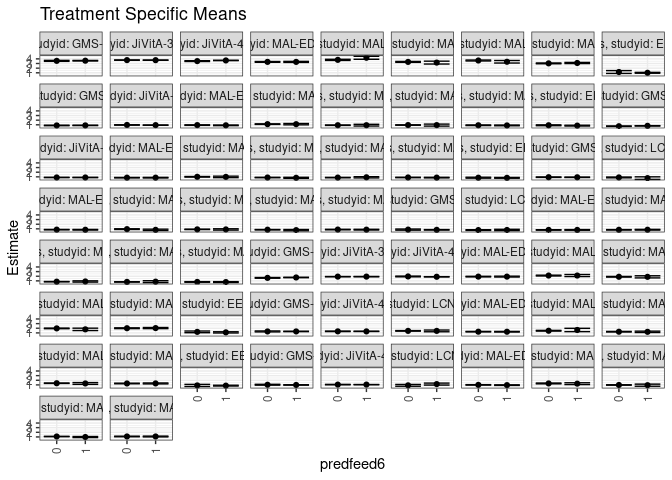

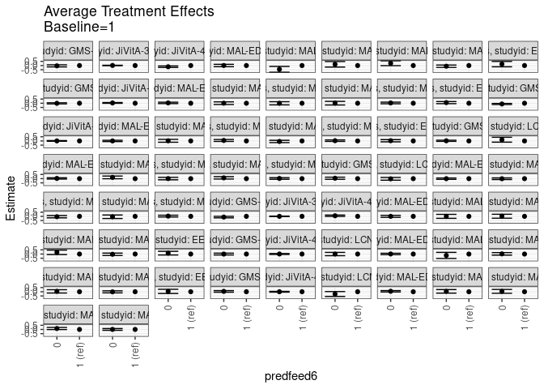

[figure not shown]

## Results Table

### Parameter: TSM

| agecat | studyid | country | intervention_level | baseline_level | estimate | ci_lower | ci_upper |
| --- | --- | --- | --- | --- | --- | --- | --- |
| 0-3 months | GMS-Nepal | NEPAL | 1 | NA | 3.6073848 | 3.5489377 | 3.6658319 |
| 0-3 months | GMS-Nepal | NEPAL | 0 | NA | 3.5723675 | 3.4625457 | 3.6821892 |
| 0-3 months | JiVitA-3 | BANGLADESH | 1 | NA | 3.7225844 | 3.7090714 | 3.7360975 |
| 0-3 months | JiVitA-3 | BANGLADESH | 0 | NA | 3.7343999 | 3.7111346 | 3.7576651 |
| 0-3 months | JiVitA-4 | BANGLADESH | 1 | NA | 3.6620162 | 3.6290472 | 3.6949851 |
| 0-3 months | JiVitA-4 | BANGLADESH | 0 | NA | 3.5189718 | 3.4332502 | 3.6046934 |
| 0-3 months | MAL-ED | BANGLADESH | 1 | NA | 3.3474372 | 3.2342411 | 3.4606334 |
| 0-3 months | MAL-ED | BANGLADESH | 0 | NA | 3.3513696 | 3.2656995 | 3.4370397 |
| 0-3 months | MAL-ED | BRAZIL | 1 | NA | 4.2389719 | 3.9131023 | 4.5648415 |
| 0-3 months | MAL-ED | BRAZIL | 0 | NA | 3.7888851 | 3.6718191 | 3.9059510 |
| 0-3 months | MAL-ED | INDIA | 1 | NA | 3.1975488 | 2.8853961 | 3.5097015 |
| 0-3 months | MAL-ED | INDIA | 0 | NA | 3.3449364 | 3.2480037 | 3.4418691 |
| 0-3 months | MAL-ED | NEPAL | 1 | NA | 3.3756712 | 3.0999388 | 3.6514035 |
| 0-3 months | MAL-ED | NEPAL | 0 | NA | 3.6513989 | 3.5505305 | 3.7522672 |
| 0-3 months | MAL-ED | PERU | 1 | NA | 3.1146134 | 2.9978634 | 3.2313634 |
| 0-3 months | MAL-ED | PERU | 0 | NA | 3.0333539 | 2.9529801 | 3.1137276 |
| 3-6 months | GMS-Nepal | NEPAL | 1 | NA | 1.7321467 | 1.6862692 | 1.7780242 |
| 3-6 months | GMS-Nepal | NEPAL | 0 | NA | 1.6448132 | 1.5650285 | 1.7245979 |
| 3-6 months | JiVitA-3 | BANGLADESH | 1 | NA | 1.9189304 | 1.9037345 | 1.9341263 |
| 3-6 months | JiVitA-3 | BANGLADESH | 0 | NA | 1.9180685 | 1.8936404 | 1.9424966 |
| 3-6 months | JiVitA-4 | BANGLADESH | 1 | NA | 1.8836835 | 1.8507942 | 1.9165728 |
| 3-6 months | JiVitA-4 | BANGLADESH | 0 | NA | 1.9539946 | 1.8771959 | 2.0307932 |
| 3-6 months | MAL-ED | BANGLADESH | 1 | NA | 1.9162938 | 1.8222890 | 2.0102985 |
| 3-6 months | MAL-ED | BANGLADESH | 0 | NA | 1.9160472 | 1.8546736 | 1.9774208 |
| 3-6 months | MAL-ED | BRAZIL | 1 | NA | 2.1487891 | 1.9269977 | 2.3705804 |
| 3-6 months | MAL-ED | BRAZIL | 0 | NA | 2.1489819 | 2.0637844 | 2.2341795 |
| 3-6 months | MAL-ED | INDIA | 1 | NA | 1.8694055 | 1.6438987 | 2.0949123 |
| 3-6 months | MAL-ED | INDIA | 0 | NA | 1.8846146 | 1.8157367 | 1.9534926 |
| 3-6 months | MAL-ED | NEPAL | 1 | NA | 1.7635822 | 1.5065838 | 2.0205807 |
| 3-6 months | MAL-ED | NEPAL | 0 | NA | 1.9702530 | 1.9099858 | 2.0305202 |

[output cut: 100 more lines]

### Parameter: E(Y)

| agecat | studyid | country | intervention_level | baseline_level | estimate | ci_lower | ci_upper |
| --- | --- | --- | --- | --- | --- | --- | --- |
| 0-3 months | GMS-Nepal | NEPAL | NA | NA | 3.5982617 | 3.5465367 | 3.6499867 |
| 0-3 months | JiVitA-3 | BANGLADESH | NA | NA | 3.7251075 | 3.7124931 | 3.7377219 |
| 0-3 months | JiVitA-4 | BANGLADESH | NA | NA | 3.6386843 | 3.6074983 | 3.6698703 |
| 0-3 months | MAL-ED | BANGLADESH | NA | NA | 3.3482498 | 3.2804281 | 3.4160715 |
| 0-3 months | MAL-ED | BRAZIL | NA | NA | 3.8190367 | 3.7078440 | 3.9302295 |
| 0-3 months | MAL-ED | INDIA | NA | NA | 3.3378760 | 3.2442606 | 3.4314913 |
| 0-3 months | MAL-ED | NEPAL | NA | NA | 3.6205791 | 3.5251464 | 3.7160118 |
| 0-3 months | MAL-ED | PERU | NA | NA | 3.0614469 | 2.9957442 | 3.1271496 |
| 3-6 months | GMS-Nepal | NEPAL | NA | NA | 1.7086613 | 1.6690533 | 1.7482692 |
| 3-6 months | JiVitA-3 | BANGLADESH | NA | NA | 1.9190532 | 1.9057476 | 1.9323587 |
| 3-6 months | JiVitA-4 | BANGLADESH | NA | NA | 1.8947099 | 1.8645495 | 1.9248703 |
| 3-6 months | MAL-ED | BANGLADESH | NA | NA | 1.9247979 | 1.8735932 | 1.9760025 |
| 3-6 months | MAL-ED | BRAZIL | NA | NA | 2.1460815 | 2.0668679 | 2.2252951 |
| 3-6 months | MAL-ED | INDIA | NA | NA | 1.8843292 | 1.8181080 | 1.9505504 |
| 3-6 months | MAL-ED | NEPAL | NA | NA | 1.9668794 | 1.9086855 | 2.0250732 |
| 3-6 months | MAL-ED | PERU | NA | NA | 2.0171026 | 1.9506965 | 2.0835088 |
| 6-9 months | EE | PAKISTAN | NA | NA | 1.1260884 | 1.0085133 | 1.2436636 |
| 6-9 months | GMS-Nepal | NEPAL | NA | NA | 1.3140299 | 1.2729534 | 1.3551064 |
| 6-9 months | JiVitA-4 | BANGLADESH | NA | NA | 1.3251314 | 1.3038170 | 1.3464459 |
| 6-9 months | LCNI-5 | MALAWI | NA | NA | 1.4372604 | 1.3755150 | 1.4990057 |
| 6-9 months | MAL-ED | BANGLADESH | NA | NA | 1.2541293 | 1.2135456 | 1.2947130 |
| 6-9 months | MAL-ED | BRAZIL | NA | NA | 1.4831159 | 1.4026580 | 1.5635738 |
| 6-9 months | MAL-ED | INDIA | NA | NA | 1.2497455 | 1.1971145 | 1.3023766 |
| 6-9 months | MAL-ED | NEPAL | NA | NA | 1.3520991 | 1.3076136 | 1.3965845 |
| 6-9 months | MAL-ED | PERU | NA | NA | 1.3199965 | 1.2656612 | 1.3743319 |
| 9-12 months | EE | PAKISTAN | NA | NA | 0.8484117 | 0.7632855 | 0.9335379 |
| 9-12 months | GMS-Nepal | NEPAL | NA | NA | 0.9981924 | 0.9647527 | 1.0316321 |
| 9-12 months | JiVitA-4 | BANGLADESH | NA | NA | 1.0696646 | 1.0503114 | 1.0890177 |
| 9-12 months | LCNI-5 | MALAWI | NA | NA | 0.9706344 | 0.8246089 | 1.1166600 |
| 9-12 months | MAL-ED | BANGLADESH | NA | NA | 0.9848124 | 0.9457805 | 1.0238444 |
| 9-12 months | MAL-ED | BRAZIL | NA | NA | 1.2982559 | 1.2240694 | 1.3724425 |
| 9-12 months | MAL-ED | INDIA | NA | NA | 0.9824181 | 0.9426109 | 1.0222252 |
| 9-12 months | MAL-ED | NEPAL | NA | NA | 1.0864239 | 1.0443515 | 1.1284963 |
| 9-12 months | MAL-ED | PERU | NA | NA | 1.0985124 | 1.0475959 | 1.1494289 |
| 12-15 months | EE | PAKISTAN | NA | NA | 1.0223758 | 0.9334119 | 1.1113396 |
| 12-15 months | GMS-Nepal | NEPAL | NA | NA | 0.8704063 | 0.8447703 | 0.8960424 |
| 12-15 months | JiVitA-4 | BANGLADESH | NA | NA | 0.9393119 | 0.9219119 | 0.9567119 |
| 12-15 months | MAL-ED | BANGLADESH | NA | NA | 0.9199912 | 0.8786810 | 0.9613015 |
| 12-15 months | MAL-ED | BRAZIL | NA | NA | 1.1421774 | 1.0831447 | 1.2012100 |
| 12-15 months | MAL-ED | INDIA | NA | NA | 0.9104871 | 0.8696624 | 0.9513117 |
| 12-15 months | MAL-ED | NEPAL | NA | NA | 0.9495446 | 0.9093518 | 0.9897373 |
| 12-15 months | MAL-ED | PERU | NA | NA | 0.8917280 | 0.8454370 | 0.9380189 |
| 15-18 months | EE | PAKISTAN | NA | NA | 0.8381757 | 0.7627800 | 0.9135715 |
| 15-18 months | GMS-Nepal | NEPAL | NA | NA | 0.7603933 | 0.7281594 | 0.7926271 |
| 15-18 months | JiVitA-4 | BANGLADESH | NA | NA | 0.8612746 | 0.8433730 | 0.8791761 |
| 15-18 months | MAL-ED | BANGLADESH | NA | NA | 0.8230330 | 0.7852223 | 0.8608436 |
| 15-18 months | MAL-ED | BRAZIL | NA | NA | 1.0021114 | 0.9429996 | 1.0612232 |
| 15-18 months | MAL-ED | INDIA | NA | NA | 0.8475479 | 0.8106803 | 0.8844155 |
| 15-18 months | MAL-ED | NEPAL | NA | NA | 0.8425951 | 0.7997829 | 0.8854074 |
| 15-18 months | MAL-ED | PERU | NA | NA | 0.8534307 | 0.8111406 | 0.8957208 |
| 18-21 months | EE | PAKISTAN | NA | NA | 0.7870620 | 0.7131718 | 0.8609522 |
| 18-21 months | GMS-Nepal | NEPAL | NA | NA | 0.9058703 | 0.8708102 | 0.9409303 |
| 18-21 months | LCNI-5 | MALAWI | NA | NA | 0.8419773 | 0.7481346 | 0.9358201 |
| 18-21 months | MAL-ED | BANGLADESH | NA | NA | 0.8195860 | 0.7845702 | 0.8546019 |
| 18-21 months | MAL-ED | BRAZIL | NA | NA | 0.9160758 | 0.8452655 | 0.9868862 |
| 18-21 months | MAL-ED | INDIA | NA | NA | 0.8782845 | 0.8424042 | 0.9141648 |
| 18-21 months | MAL-ED | NEPAL | NA | NA | 0.8108531 | 0.7724296 | 0.8492765 |
| 18-21 months | MAL-ED | PERU | NA | NA | 0.8414439 | 0.7967949 | 0.8860929 |
| 21-24 months | GMS-Nepal | NEPAL | NA | NA | 0.7949572 | 0.7486969 | 0.8412176 |
| 21-24 months | LCNI-5 | MALAWI | NA | NA | 0.7342569 | 0.6662316 | 0.8022822 |
| 21-24 months | MAL-ED | BANGLADESH | NA | NA | 0.7717324 | 0.7354003 | 0.8080644 |
| 21-24 months | MAL-ED | BRAZIL | NA | NA | 0.7961519 | 0.7521041 | 0.8401997 |
| 21-24 months | MAL-ED | INDIA | NA | NA | 0.8278900 | 0.7955176 | 0.8602624 |
| 21-24 months | MAL-ED | NEPAL | NA | NA | 0.7862274 | 0.7444562 | 0.8279985 |
| 21-24 months | MAL-ED | PERU | NA | NA | 0.7610506 | 0.7141593 | 0.8079419 |

### Parameter: ATE

| agecat | studyid | country | intervention_level | baseline_level | estimate | ci_lower | ci_upper |
| --- | --- | --- | --- | --- | --- | --- | --- |
| 0-3 months | GMS-Nepal | NEPAL | 1 | 1 | 0.0000000 | 0.0000000 | 0.0000000 |
| 0-3 months | GMS-Nepal | NEPAL | 0 | 1 | -0.0350173 | -0.1594850 | 0.0894503 |
| 0-3 months | JiVitA-3 | BANGLADESH | 1 | 1 | 0.0000000 | 0.0000000 | 0.0000000 |
| 0-3 months | JiVitA-3 | BANGLADESH | 0 | 1 | 0.0118154 | -0.0126218 | 0.0362527 |
| 0-3 months | JiVitA-4 | BANGLADESH | 1 | 1 | 0.0000000 | 0.0000000 | 0.0000000 |
| 0-3 months | JiVitA-4 | BANGLADESH | 0 | 1 | -0.1430444 | -0.2346358 | -0.0514529 |
| 0-3 months | MAL-ED | BANGLADESH | 1 | 1 | 0.0000000 | 0.0000000 | 0.0000000 |
| 0-3 months | MAL-ED | BANGLADESH | 0 | 1 | 0.0039324 | -0.1386486 | 0.1465134 |
| 0-3 months | MAL-ED | BRAZIL | 1 | 1 | 0.0000000 | 0.0000000 | 0.0000000 |
| 0-3 months | MAL-ED | BRAZIL | 0 | 1 | -0.4500868 | -0.7982165 | -0.1019571 |
| 0-3 months | MAL-ED | INDIA | 1 | 1 | 0.0000000 | 0.0000000 | 0.0000000 |
| 0-3 months | MAL-ED | INDIA | 0 | 1 | 0.1473877 | -0.1794690 | 0.4742443 |
| 0-3 months | MAL-ED | NEPAL | 1 | 1 | 0.0000000 | 0.0000000 | 0.0000000 |
| 0-3 months | MAL-ED | NEPAL | 0 | 1 | 0.2757277 | -0.0161556 | 0.5676110 |
| 0-3 months | MAL-ED | PERU | 1 | 1 | 0.0000000 | 0.0000000 | 0.0000000 |
| 0-3 months | MAL-ED | PERU | 0 | 1 | -0.0812595 | -0.2233127 | 0.0607936 |
| 3-6 months | GMS-Nepal | NEPAL | 1 | 1 | 0.0000000 | 0.0000000 | 0.0000000 |
| 3-6 months | GMS-Nepal | NEPAL | 0 | 1 | -0.0873335 | -0.1799719 | 0.0053048 |
| 3-6 months | JiVitA-3 | BANGLADESH | 1 | 1 | 0.0000000 | 0.0000000 | 0.0000000 |
| 3-6 months | JiVitA-3 | BANGLADESH | 0 | 1 | -0.0008619 | -0.0287582 | 0.0270344 |
| 3-6 months | JiVitA-4 | BANGLADESH | 1 | 1 | 0.0000000 | 0.0000000 | 0.0000000 |
| 3-6 months | JiVitA-4 | BANGLADESH | 0 | 1 | 0.0703111 | -0.0130304 | 0.1536526 |
| 3-6 months | MAL-ED | BANGLADESH | 1 | 1 | 0.0000000 | 0.0000000 | 0.0000000 |
| 3-6 months | MAL-ED | BANGLADESH | 0 | 1 | -0.0002466 | -0.1153181 | 0.1148249 |
| 3-6 months | MAL-ED | BRAZIL | 1 | 1 | 0.0000000 | 0.0000000 | 0.0000000 |
| 3-6 months | MAL-ED | BRAZIL | 0 | 1 | 0.0001929 | -0.2376636 | 0.2380493 |
| 3-6 months | MAL-ED | INDIA | 1 | 1 | 0.0000000 | 0.0000000 | 0.0000000 |
| 3-6 months | MAL-ED | INDIA | 0 | 1 | 0.0152091 | -0.2209727 | 0.2513909 |
| 3-6 months | MAL-ED | NEPAL | 1 | 1 | 0.0000000 | 0.0000000 | 0.0000000 |
| 3-6 months | MAL-ED | NEPAL | 0 | 1 | 0.2066708 | -0.0578329 | 0.4711744 |

[output cut: 100 more lines]

### Parameter: PAR

| agecat | studyid | country | intervention_level | baseline_level | estimate | ci_lower | ci_upper |
| --- | --- | --- | --- | --- | --- | --- | --- |
| 0-3 months | GMS-Nepal | NEPAL | 1 | NA | -0.0091231 | -0.0417380 | 0.0234919 |
| 0-3 months | JiVitA-3 | BANGLADESH | 1 | NA | 0.0025231 | -0.0029953 | 0.0080414 |
| 0-3 months | JiVitA-4 | BANGLADESH | 1 | NA | -0.0233319 | -0.0383515 | -0.0083123 |
| 0-3 months | MAL-ED | BANGLADESH | 1 | NA | 0.0008126 | -0.0917918 | 0.0934169 |
| 0-3 months | MAL-ED | BRAZIL | 1 | NA | -0.4199352 | -0.7279468 | -0.1119235 |
| 0-3 months | MAL-ED | INDIA | 1 | NA | 0.1403272 | -0.1709085 | 0.4515629 |
| 0-3 months | MAL-ED | NEPAL | 1 | NA | 0.2449080 | -0.0329932 | 0.5228091 |
| 0-3 months | MAL-ED | PERU | 1 | NA | -0.0531665 | -0.1484960 | 0.0421631 |
| 3-6 months | GMS-Nepal | NEPAL | 1 | NA | -0.0234854 | -0.0489023 | 0.0019315 |
| 3-6 months | JiVitA-3 | BANGLADESH | 1 | NA | 0.0001228 | -0.0063985 | 0.0066441 |
| 3-6 months | JiVitA-4 | BANGLADESH | 1 | NA | 0.0110264 | -0.0017013 | 0.0237542 |
| 3-6 months | MAL-ED | BANGLADESH | 1 | NA | 0.0085041 | -0.0664936 | 0.0835017 |
| 3-6 months | MAL-ED | BRAZIL | 1 | NA | -0.0027075 | -0.2075445 | 0.2021294 |
| 3-6 months | MAL-ED | INDIA | 1 | NA | 0.0149237 | -0.2096530 | 0.2395004 |
| 3-6 months | MAL-ED | NEPAL | 1 | NA | 0.2032971 | -0.0504048 | 0.4569991 |
| 3-6 months | MAL-ED | PERU | 1 | NA | -0.0182241 | -0.1126109 | 0.0761628 |
| 6-9 months | EE | PAKISTAN | 1 | NA | 0.0116647 | -0.0144891 | 0.0378184 |
| 6-9 months | GMS-Nepal | NEPAL | 1 | NA | 0.0007529 | -0.0269804 | 0.0284861 |
| 6-9 months | JiVitA-4 | BANGLADESH | 1 | NA | 0.0013990 | -0.0090120 | 0.0118099 |
| 6-9 months | LCNI-5 | MALAWI | 1 | NA | 0.0050099 | -0.1622488 | 0.1722687 |
| 6-9 months | MAL-ED | BANGLADESH | 1 | NA | 0.0057450 | -0.0508031 | 0.0622931 |
| 6-9 months | MAL-ED | BRAZIL | 1 | NA | -0.1416213 | -0.4597147 | 0.1764721 |
| 6-9 months | MAL-ED | INDIA | 1 | NA | 0.0220161 | -0.1211746 | 0.1652068 |
| 6-9 months | MAL-ED | NEPAL | 1 | NA | 0.0372485 | -0.1503257 | 0.2248227 |
| 6-9 months | MAL-ED | PERU | 1 | NA | -0.0030081 | -0.0825830 | 0.0765669 |
| 9-12 months | EE | PAKISTAN | 1 | NA | 0.0049059 | -0.0238483 | 0.0336600 |
| 9-12 months | GMS-Nepal | NEPAL | 1 | NA | 0.0091212 | -0.0136627 | 0.0319050 |
| 9-12 months | JiVitA-4 | BANGLADESH | 1 | NA | 0.0009133 | -0.0087668 | 0.0105934 |
| 9-12 months | LCNI-5 | MALAWI | 1 | NA | -0.2068640 | -0.4166769 | 0.0029489 |
| 9-12 months | MAL-ED | BANGLADESH | 1 | NA | 0.0340253 | -0.0201212 | 0.0881719 |
| 9-12 months | MAL-ED | BRAZIL | 1 | NA | 0.0265561 | -0.1550797 | 0.2081918 |
| 9-12 months | MAL-ED | INDIA | 1 | NA | 0.0416157 | -0.1769523 | 0.2601836 |
| 9-12 months | MAL-ED | NEPAL | 1 | NA | 0.1087447 | -0.0109336 | 0.2284230 |
| 9-12 months | MAL-ED | PERU | 1 | NA | 0.0024904 | -0.0662671 | 0.0712479 |
| 12-15 months | EE | PAKISTAN | 1 | NA | 0.0229376 | -0.0239780 | 0.0698531 |
| 12-15 months | GMS-Nepal | NEPAL | 1 | NA | -0.0027816 | -0.0185562 | 0.0129930 |
| 12-15 months | JiVitA-4 | BANGLADESH | 1 | NA | 0.0081601 | -0.0015555 | 0.0178756 |
| 12-15 months | MAL-ED | BANGLADESH | 1 | NA | 0.0268969 | -0.0274665 | 0.0812603 |
| 12-15 months | MAL-ED | BRAZIL | 1 | NA | 0.0054330 | -0.1300680 | 0.1409339 |
| 12-15 months | MAL-ED | INDIA | 1 | NA | -0.0067119 | -0.1876373 | 0.1742136 |
| 12-15 months | MAL-ED | NEPAL | 1 | NA | 0.0125851 | -0.1950484 | 0.2202187 |
| 12-15 months | MAL-ED | PERU | 1 | NA | 0.0246057 | -0.0401723 | 0.0893837 |
| 15-18 months | EE | PAKISTAN | 1 | NA | 0.0116807 | -0.0096621 | 0.0330235 |
| 15-18 months | GMS-Nepal | NEPAL | 1 | NA | -0.0208275 | -0.0366680 | -0.0049870 |
| 15-18 months | JiVitA-4 | BANGLADESH | 1 | NA | 0.0021051 | -0.0065381 | 0.0107483 |
| 15-18 months | MAL-ED | BANGLADESH | 1 | NA | 0.0011637 | -0.0496083 | 0.0519357 |
| 15-18 months | MAL-ED | BRAZIL | 1 | NA | 0.0180878 | -0.1293504 | 0.1655260 |
| 15-18 months | MAL-ED | INDIA | 1 | NA | 0.0563875 | -0.0534131 | 0.1661882 |
| 15-18 months | MAL-ED | NEPAL | 1 | NA | -0.0573310 | -0.1869021 | 0.0722401 |
| 15-18 months | MAL-ED | PERU | 1 | NA | 0.0212809 | -0.0344178 | 0.0769796 |
| 18-21 months | EE | PAKISTAN | 1 | NA | 0.0041563 | -0.0160395 | 0.0243522 |
| 18-21 months | GMS-Nepal | NEPAL | 1 | NA | 0.0039851 | -0.0120418 | 0.0200121 |
| 18-21 months | LCNI-5 | MALAWI | 1 | NA | 0.1197675 | -0.1075790 | 0.3471141 |
| 18-21 months | MAL-ED | BANGLADESH | 1 | NA | 0.0144943 | -0.0342695 | 0.0632581 |
| 18-21 months | MAL-ED | BRAZIL | 1 | NA | 0.1277078 | -0.0102098 | 0.2656253 |
| 18-21 months | MAL-ED | INDIA | 1 | NA | 0.0011027 | -0.1397345 | 0.1419399 |
| 18-21 months | MAL-ED | NEPAL | 1 | NA | 0.0873139 | -0.0462745 | 0.2209023 |
| 18-21 months | MAL-ED | PERU | 1 | NA | 0.0143172 | -0.0482864 | 0.0769208 |
| 21-24 months | GMS-Nepal | NEPAL | 1 | NA | 0.0059266 | -0.0237006 | 0.0355538 |
| 21-24 months | LCNI-5 | MALAWI | 1 | NA | -0.0207605 | -0.1565776 | 0.1150567 |
| 21-24 months | MAL-ED | BANGLADESH | 1 | NA | 0.0010352 | -0.0520084 | 0.0540788 |
| 21-24 months | MAL-ED | BRAZIL | 1 | NA | -0.0120052 | -0.0936889 | 0.0696785 |
| 21-24 months | MAL-ED | INDIA | 1 | NA | -0.0442856 | -0.1731539 | 0.0845827 |
| 21-24 months | MAL-ED | NEPAL | 1 | NA | -0.0415805 | -0.2391561 | 0.1559951 |
| 21-24 months | MAL-ED | PERU | 1 | NA | 0.0185374 | -0.0515649 | 0.0886397 |